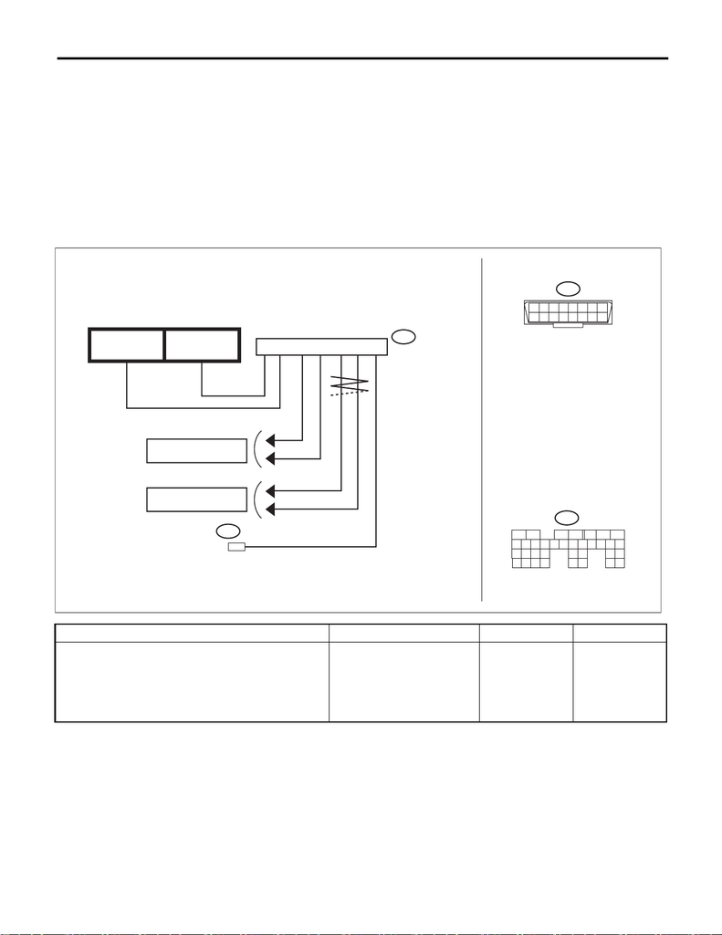

LAN(diag)-11

Subaru Select Monitor

LAN SYSTEM (DIAGNOSTICS)

6. Subaru Select Monitor

A: OPERATION

For details of basic operations, refer to “PC application help for Subaru Select Monitor”.

B: COMMUNICATION FOR INITIALIZING IMPOSSIBLE

DIAGNOSIS:

Subaru Select Monitor communication line is open or shorted.

TROUBLE SYMPTOM:

Not communicable with Subaru Select Monitor.

WIRING DIAGRAM:

CAN communication system <Ref. to WI-110, WIRING DIAGRAM, CAN Communication System.>

Step Check Yes No

1 CHECK SUBARU SELECT MONITOR.

1) Connect the Subaru Select Monitor to

another vehicle.

2) Check communication condition between

Subaru Select Monitor and vehicle.

Is communication performed

normally?

Go to step 2. Subaru Select

Monitor unit or

diagnosis cable is

faulty. Or check the

fuse on the vehicle

side.

B135

19

18

21

20

2322 24 25

26

17

12

34 567

27

28 29 30 31

32 33

34 35

98

151413121110 16

B40

1

9

8

16

2

10

7

15

3

11

6

14

4

12

5

13

CAN Lo

CAN Hi

IGN

GND

GND

+B

B135

B:

14

B40

7

14

6

4

5

8

16

LAN01443

K-Line

ECM

MB-27

M/B FUSE NO. 13

(B)

FB-32

F/B FUSE NO. 4

(IG)

DATA LINK

CONNECTOR

REF. TO ENGINE

ELECTRICAL SYSTEM

REF. TO CAN

COMMUNICATION SYSTEM

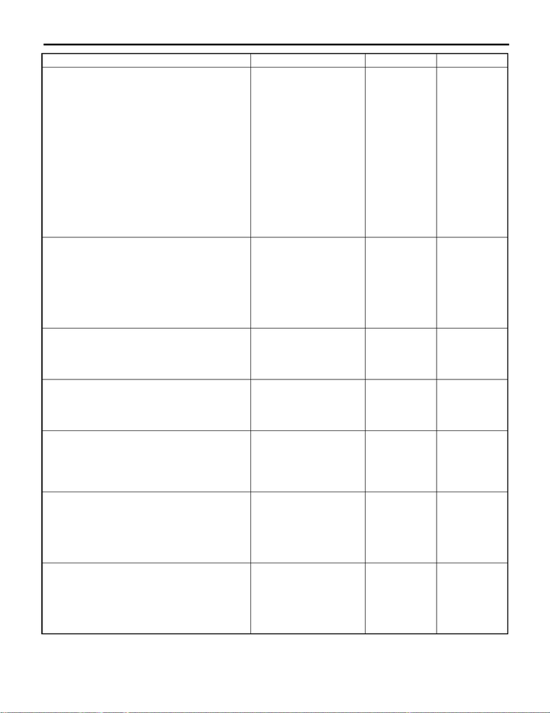

LAN(diag)-12

Subaru Select Monitor

LAN SYSTEM (DIAGNOSTICS)

2 CHECK COMMUNICATION FOR INITIALIZ-

ING ERROR.

Perform the communication for initializing with

each module by connecting the Subaru Select

Monitor. (For systems whose module can com-

municate with diagnostic devices)

Is the communication possible

with all modules?

For engine type EJ,

Go to step 3.

For engine type

FA, Go to step 9.

Perform the

inspection using

the check sheet of

communication for

initializing. <Ref. to

LAN(diag)-13,

CHECK USING

THE CHECK

SHEET OF COM-

MUNICATION

FOR INITIALIZ-

ING, COMMUNI-

CATION FOR

INITIALIZING

IMPOSSIBLE,

Subaru Select

Monitor.>

3 CHECK K-LINE.

1) Establish the communication between

Select Monitor and K-Line communication mod-

ule.

2) Using a tester, check continuity between the

modules that did not communicate with Select

Monitor.

Connector & terminal

(B40) No. 7 — (B135) No. 14 (ECM):

Is there continuity? Go to step 4. Repair or replace

the open circuit.

4 CHECK K-LINE.

Using a tester, check continuity between K-line

and chassis ground.

Connector & terminal

(B40) No. 7 — Chassis ground:

Is there continuity? Repair or replace

the short circuit

portion.

Go to step 5.

5 CHECK K-LINE.

Using a tester, check voltage between K-line

and chassis ground.

Connector & terminal

(B40) No. 7 (+) — Chassis ground (–):

Is the voltage 5 V or more with

IG ON?

Repair or replace

the short circuit

portion.

Go to step 6.

6 CHECK K-LINE.

Use a tester to check for continuity in the ground

circuit.

Connector & terminal

(B40) No. 4 — Chassis ground:

(B40) No. 5 — Chassis ground:

Is there continuity? Go to step 8. Go to step 7.

7 CHECK K-LINE.

1) Disconnect the ECM connector.

2) Use a tester to check for continuity in the

ground circuit.

Connector & terminal

(B40) No. 4 — (B137) No. 3:

(B40) No. 5 — (B136) No. 4:

Is there continuity? Check ECM

ground.

Repair or replace

the open circuit.

8 CHECK K-LINE.

1) Turn the ignition switch to ON.

2) Using a tester, check the power supply of

data link connector.

Connector & terminal

(B40) No. 8 (+) — Chassis ground (–):

(B40) No. 16 (+) — Chassis ground (–):

Is the voltage 10 V or more? K-Line is normal.

Check the power

supply circuit of

each module.

Check the power

supply circuits to

the data link con-

nector.

Step Check Yes No

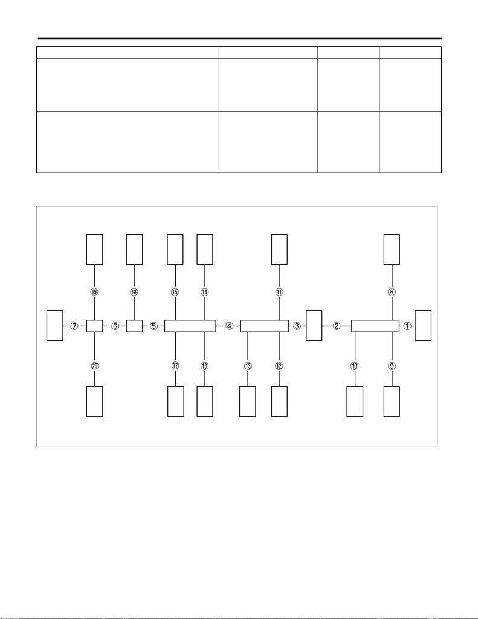

LAN(diag)-13

Subaru Select Monitor

LAN SYSTEM (DIAGNOSTICS)

1. CHECK USING THE CHECK SHEET OF COMMUNICATION FOR INITIALIZING

• Network diagram

9 CHECK DATA LINK CONNECTOR.

Use a tester to check for continuity in the ground

circuit.

Connector & terminal

(B40) No. 4 — Chassis ground:

(B40) No. 5 — Chassis ground:

Is there continuity? Go to step 10. Repair or replace

the open circuit.

10 CHECK DATA LINK CONNECTOR.

1) Turn the ignition switch to ON.

2) Using a tester, check the power supply of

data link connector.

Connector & terminal

(B40) No. 8 (+) — Chassis ground (–):

(B40) No. 16 (+) — Chassis ground (–):

the short circuit

portion.

Check the power

supply circuits to

the data link con-

nector.

Step Check Yes No

J/C J/C J/C

CVT

MFD

J/C J/C

LAN01445

ECM

DCCD CM

VDC CM

BODY

INTEGRATED

UNIT

AIRBAG CM

COMBINATION METER

A/C CONTROL PANEL

STEERING ANGLE SENSOR

REMOTE ENGINE STARTER

IMPACT SENSOR

AUTO HEADLIGHT

BEAM LEVELER CM

KEYLESS ACCESS CM

DATA LINK CONNECTOR

POWER STEERING CM

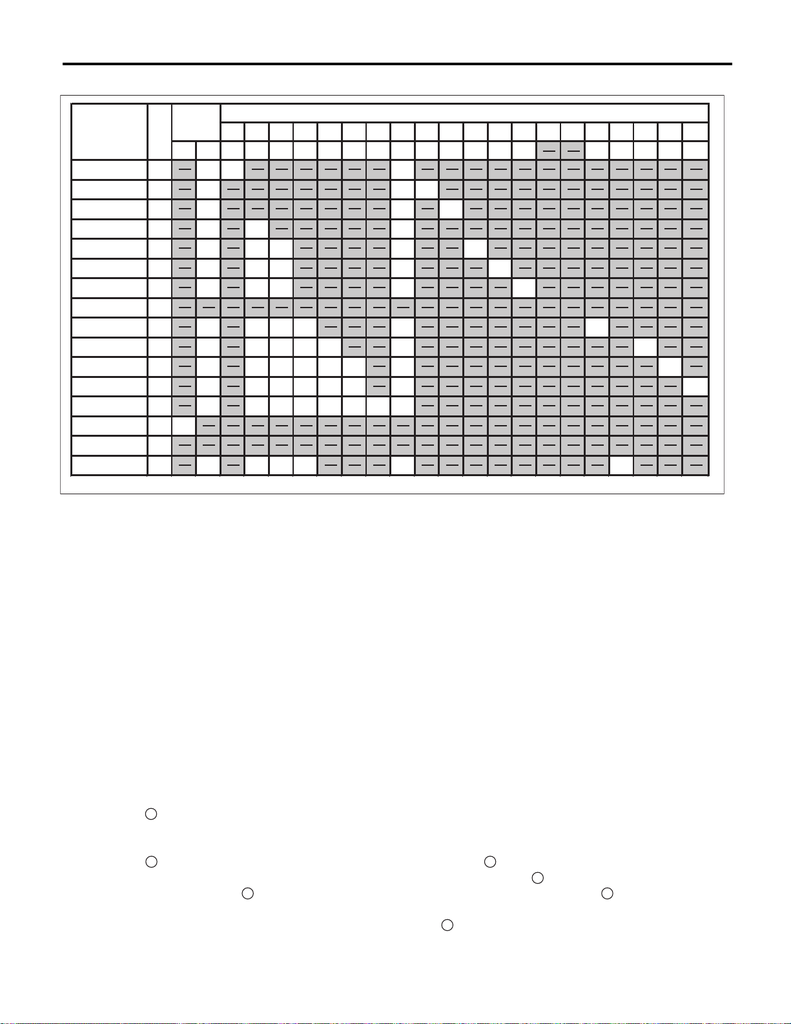

LAN(diag)-14

Subaru Select Monitor

LAN SYSTEM (DIAGNOSTICS)

• Check sheet of communication for initializing

1) Module installation check

(1) Write “-” marks in the field for installation check if the vehicle to be inspected does not have relevant

module.

(2) Write “-” marks in all blank fields on the same row that the “-” mark has filled in.

NOTE:

Example of writing <Ref. to LAN(diag)-15, EXAMPLE OF WRITING FOR THE CHECK SHEET OF COMMU-

NICATION FOR INITIALIZING, COMMUNICATION FOR INITIALIZING IMPOSSIBLE, Subaru Select Mon-

itor.>

2) SSM communication initialization check

(1) Write “ ” marks in the field for communication initialization if the module succeeded in the communi-

cation for initializing with Select Monitor.

If the communication with all modules is not possible, go to 3).

(2) Write “ ” marks in all blank fields on the same row that the “ ” mark has filled in.

(3) When at least one field in a column of wiring location is filled with the “ ” mark, then the wiring for that

location is normal. Write “ ” marks in all blank fields on the same column that the “ ” mark has filled in

under the circled number.

(4) Check the open circuit of the modules which have no “ ” mark in their columns of the wiring location

in ascending order. (only for installed modules)

(5) If the communication is not possible after checking all harnesses, check the module power supply line.

(A) Installation check VDC: VDC CM STR: Steering angle sensor

(B) Communication initialization BIU: Body integrated unit RST: Remote engine starter CM

(C) K-Line MFD: High grade MFD A/B: AB CM

(D) CAN A/C: A/C control panel EPS: Power steering CM

(E) Wiring location MET: Combination meter HL: Auto headlight beam leveler CM

CVT: TCM KPS: Keyless access CM

DCCD: DCCD CM IMP: Impact sensor

EGI (FA): ECM (engine type: FA) EGI (EJ): ECM (engine type: EJ)

LAN01444

(E)

(B)

(A)

IMP

RST

EGI(EJ)

EGI(FA)

DCCD

EPS

CVT

STR

MET

MFD

BIU

KPS

HL

VDC

(D)(C)

A/B

A/C

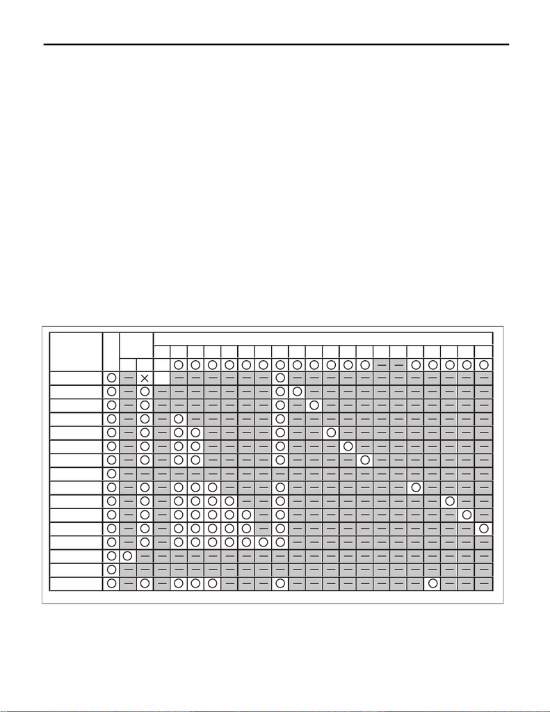

LAN(diag)-15

Subaru Select Monitor

LAN SYSTEM (DIAGNOSTICS)

(6) Replace the module if the power supply line is normal.

NOTE:

• Example of writing <Ref. to LAN(diag)-15, EXAMPLE OF WRITING FOR THE CHECK SHEET OF COM-

MUNICATION FOR INITIALIZING, COMMUNICATION FOR INITIALIZING IMPOSSIBLE, Subaru Select

Monitor.>

• Inspection using the communication for initializing of Subaru Select Monitor cannot be used to diagnose

the wiring location marked with “-”. Example of DTC data not received <Ref. to LAN(diag)-73, EXAMPLE OF

DTC DATA NOT RECEIVED, LIST, List of Diagnostic Trouble Code (DTC).> and DTC matrix <Ref. to

LAN(diag)-75, DTC MATRIX, LIST, List of Diagnostic Trouble Code (DTC).> should be used to identify the

faulty portion.

3) SSM communication initialization check (impossible to communicate with all modules)

NOTE:

If at least one module becomes possible to communicate, return to 2).

(1) Check for the short circuit to ground. <Ref. to LAN(diag)-35, GROUND SHORT INSPECTION, IN-

SPECTION, CAN Communication Circuit Check.> If it is normal, go to the next.

(2) Check for the short circuit to battery. <Ref. to LAN(diag)-37, BATTERY SHORT INSPECTION, IN-

SPECTION, CAN Communication Circuit Check.> If it is normal, go to the next.

(3) Perform the inspection for the resistance of 52 Ω or less (short between wires). <Ref. to LAN(diag)-

41, 52 Ω OR LESS, INSPECTION, CAN Communication Circuit Check.> If it is normal, go to the next.

(4) Check for the open circuit of network diagram No. 8 (data link connector).

2. EXAMPLE OF WRITING FOR THE CHECK SHEET OF COMMUNICATION FOR INITIALIZ-

ING

• When No. 1 is open

LAN01446

(E)

(B)

(A)

IMP

RST

EGI(EJ)

EGI(FA)

DCCD

EPS

CVT

STR

MET

MFD

BIU

KPS

HL

VDC

(D)(C)

A/B

A/C

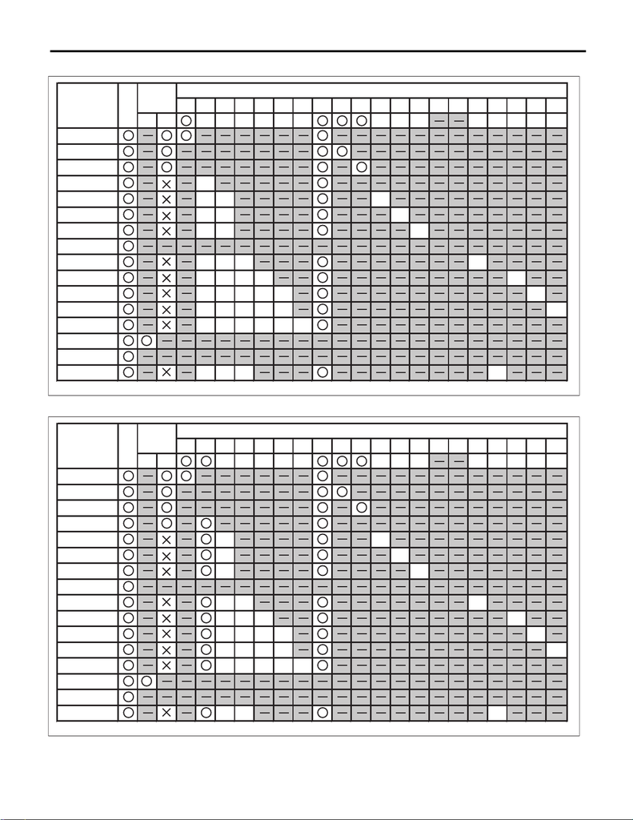

LAN(diag)-16

Subaru Select Monitor

LAN SYSTEM (DIAGNOSTICS)

• When No. 2 is open

• When No. 3 is open

LAN01447

(E)

(B)

(A)

IMP

RST

EGI(EJ)

EGI(FA)

DCCD

EPS

CVT

STR

MET

MFD

BIU

KPS

HL

VDC

(D)(C)

A/B

A/C

LAN01448

(E)

(B)

(A)

IMP

RST

EGI(EJ)

EGI(FA)

DCCD

EPS

CVT

STR

MET

MFD

BIU

KPS

HL

VDC

(D)(C)

A/B

A/C

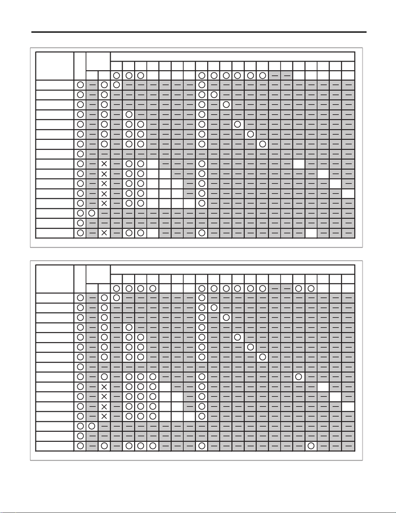

LAN(diag)-17

Subaru Select Monitor

LAN SYSTEM (DIAGNOSTICS)

• When No. 4 is open

• When No. 5 is open

LAN01449

(E)

(B)

(A)

IMP

RST

EGI(EJ)

EGI(FA)

DCCD

EPS

CVT

STR

MET

MFD

BIU

KPS

HL

VDC

(D)(C)

A/B

A/C

LAN01450

(E)

(B)

(A)

IMP

RST

EGI(EJ)

EGI(FA)

DCCD

EPS

CVT

STR

MET

MFD

BIU

KPS

HL

VDC

(D)(C)

A/B

A/C

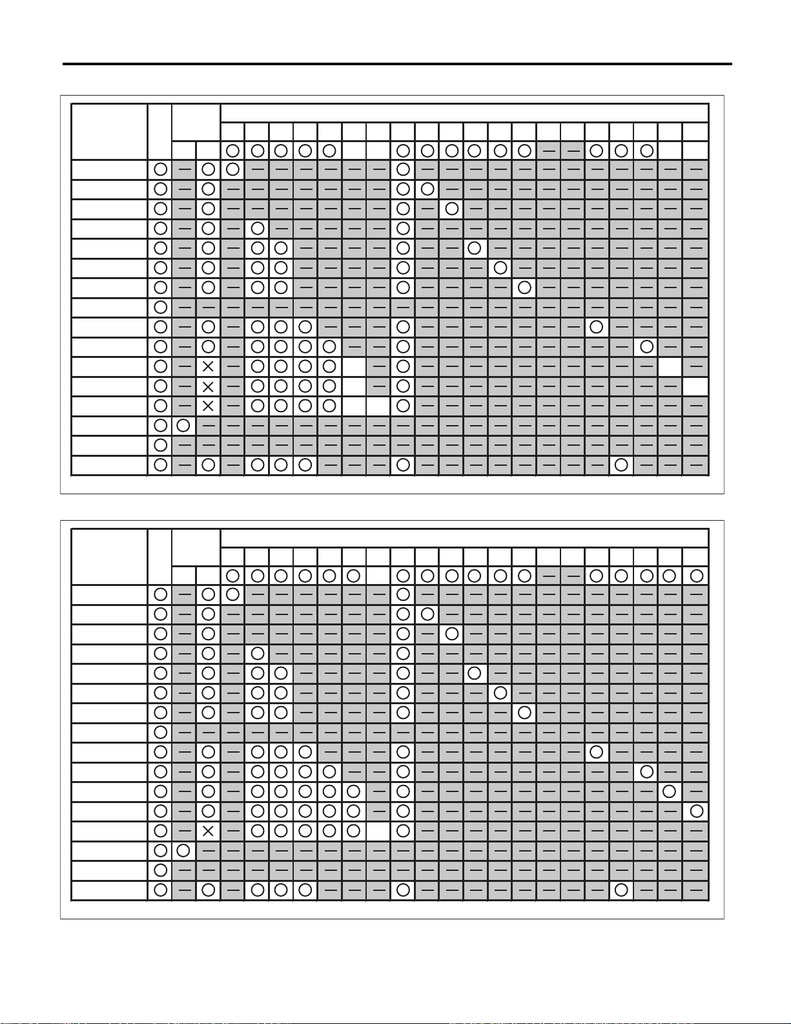

LAN(diag)-18

Subaru Select Monitor

LAN SYSTEM (DIAGNOSTICS)

• When No. 6 is open

• When No. 7 is open (engine type: FA)

LAN01451

(E)

(B)

(A)

IMP

RST

EGI(EJ)

EGI(FA)

DCCD

EPS

CVT

STR

MET

MFD

BIU

KPS

HL

VDC

(D)(C)

A/B

A/C

LAN01452

(E)

(B)

(A)

IMP

RST

EGI(EJ)

EGI(FA)

DCCD

EPS

CVT

STR

MET

MFD

BIU

KPS

HL

VDC

(D)(C)

A/B

A/C

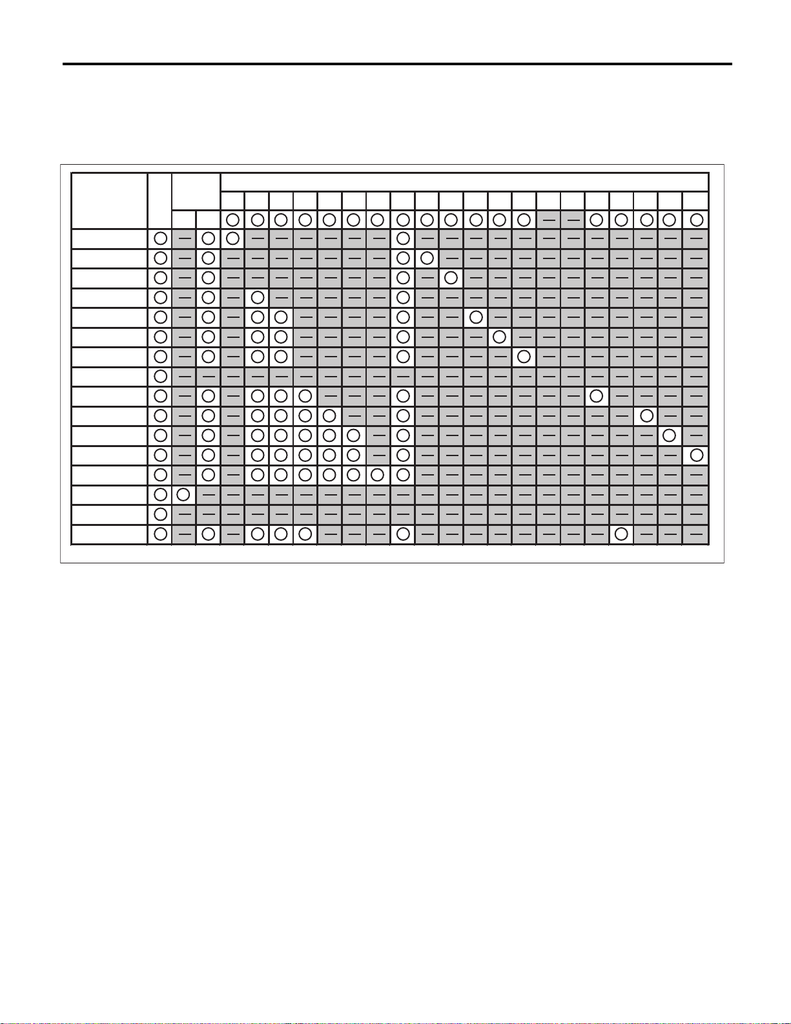

LAN(diag)-19

Subaru Select Monitor

LAN SYSTEM (DIAGNOSTICS)

• When No. 7 is open (engine type: EJ)

NOTE:

This is the same as No. 14 and No. 15, but it is possible to diagnose using examples of lost communication

detection in each module. <Ref. to LAN(diag)-73, EXAMPLE OF DTC DATA NOT RECEIVED, LIST, List of

Diagnostic Trouble Code (DTC).>

LAN01459

(E)

(B)

(A)

IMP

RST

EGI(EJ)

EGI(FA)

DCCD

EPS

CVT

STR

MET

MFD

BIU

KPS

HL

VDC

(D)(C)

A/B

A/C

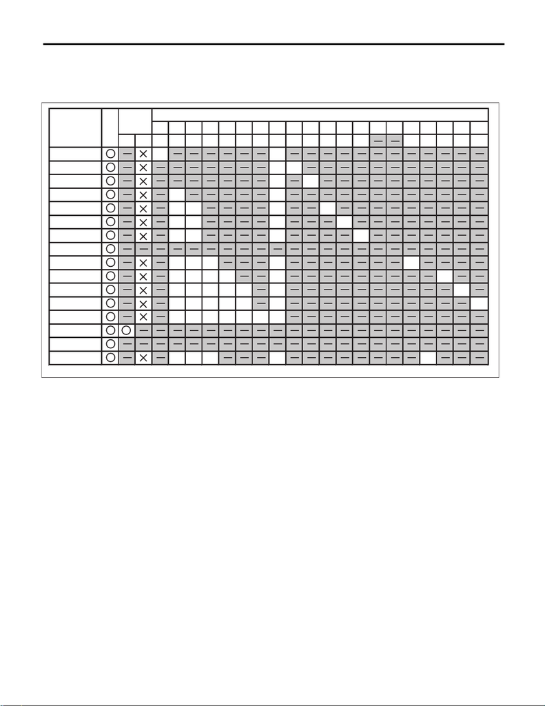

LAN(diag)-20

Subaru Select Monitor

LAN SYSTEM (DIAGNOSTICS)

• When No. 8 is open

NOTE:

3) Perform inspection by referring to the communication initialization check (impossible to communicate with

all modules). (There may be a malfunction other than open circuit)

LAN01453

(E)

(B)

(A)

IMP

RST

EGI(EJ)

EGI(FA)

DCCD

EPS

CVT

STR

MET

MFD

BIU

KPS

HL

VDC

(D)(C)

A/B

A/C

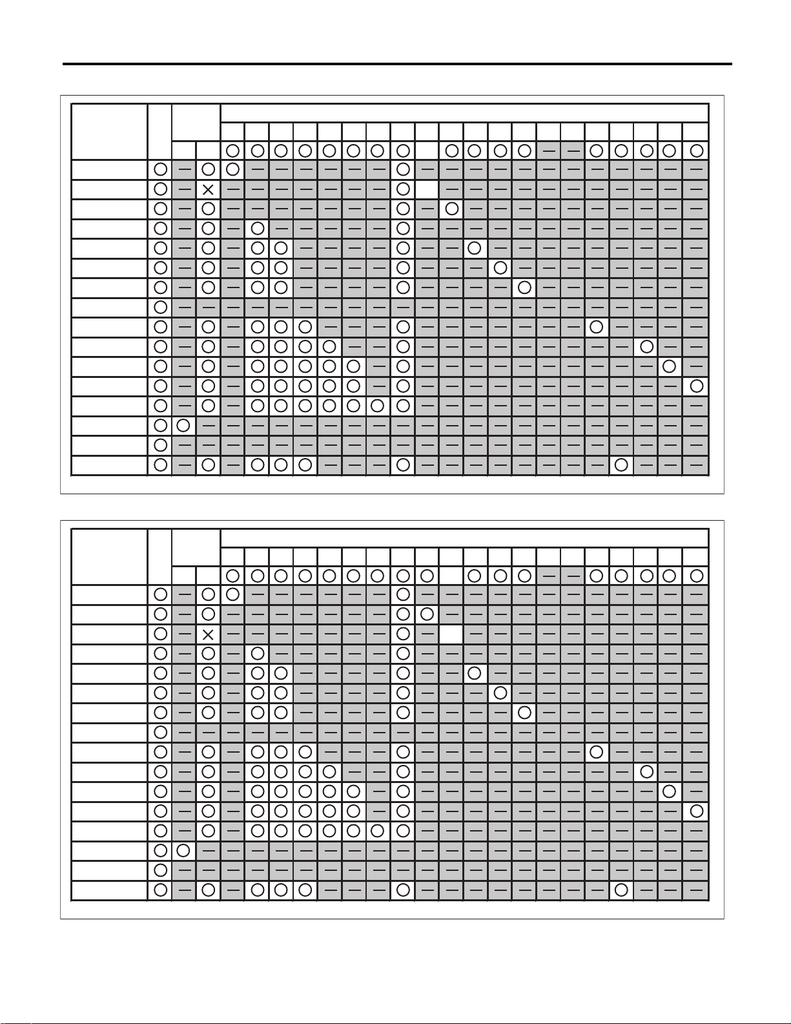

LAN(diag)-21

Subaru Select Monitor

LAN SYSTEM (DIAGNOSTICS)

• When No. 9 is open

• When No. 10 is open

LAN01454

(E)

(B)

(A)

IMP

RST

EGI(EJ)

EGI(FA)

DCCD

EPS

CVT

STR

MET

MFD

BIU

KPS

HL

VDC

(D)(C)

A/B

A/C

LAN01455

(E)

(B)

(A)

IMP

RST

EGI(EJ)

EGI(FA)

DCCD

EPS

CVT

STR

MET

MFD

BIU

KPS

HL

VDC

(D)(C)

A/B

A/C

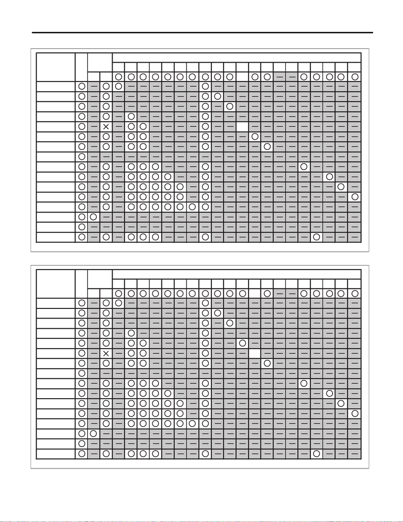

LAN(diag)-22

Subaru Select Monitor

LAN SYSTEM (DIAGNOSTICS)

• When No. 11 is open

• When No. 12 is open

LAN01456

(E)

(B)

(A)

IMP

RST

EGI(EJ)

EGI(FA)

DCCD

EPS

CVT

STR

MET

MFD

BIU

KPS

HL

VDC

(D)(C)

A/B

A/C

LAN01457

(E)

(B)

(A)

IMP

RST

EGI(EJ)

EGI(FA)

DCCD

EPS

CVT

STR

MET

MFD

BIU

KPS

HL

VDC

(D)(C)

A/B

A/C

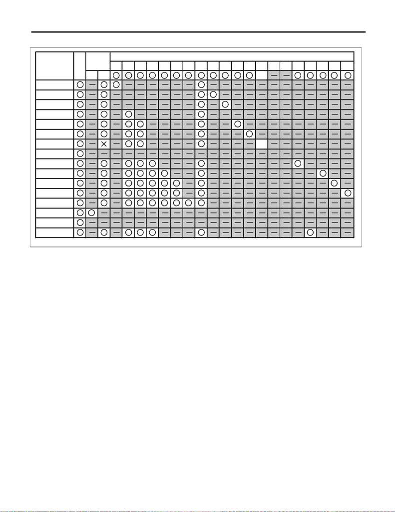

LAN(diag)-23

Subaru Select Monitor

LAN SYSTEM (DIAGNOSTICS)

• When No. 13 is open

LAN01458

(E)

(B)

(A)

IMP

RST

EGI(EJ)

EGI(FA)

DCCD

EPS

CVT

STR

MET

MFD

BIU

KPS

HL

VDC

(D)(C)

A/B

A/C

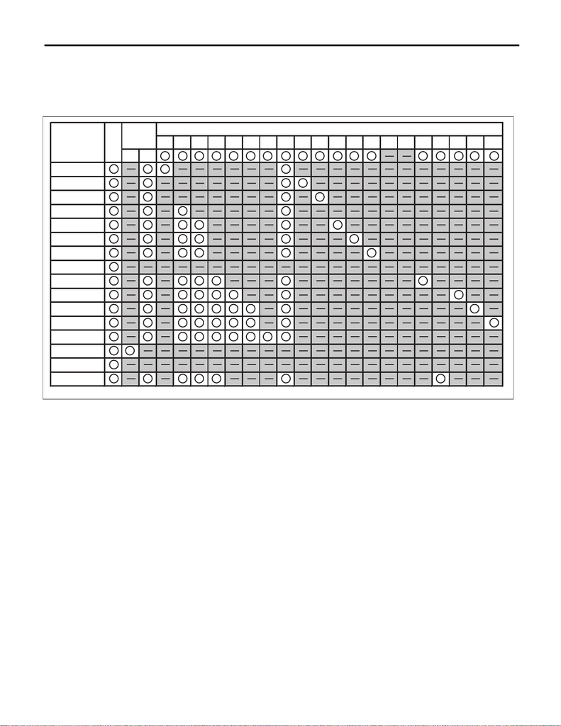

LAN(diag)-24

Subaru Select Monitor

LAN SYSTEM (DIAGNOSTICS)

• When No. 14 is open

NOTE:

This is the same as No. 7 (engine type: EJ) and No. 15, but it is possible to diagnose using examples of lost

communication detection in each module. <Ref. to LAN(diag)-73, EXAMPLE OF DTC DATA NOT RE-

CEIVED, LIST, List of Diagnostic Trouble Code (DTC).>

LAN01459

(E)

(B)

(A)

IMP

RST

EGI(EJ)

EGI(FA)

DCCD

EPS

CVT

STR

MET

MFD

BIU

KPS

HL

VDC

(D)(C)

A/B

A/C

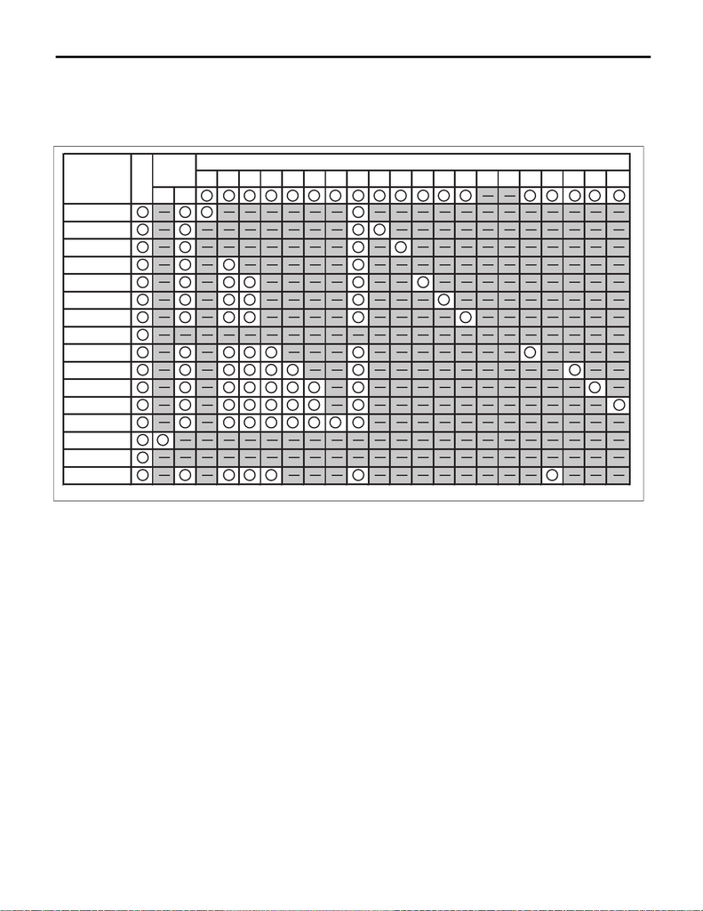

LAN(diag)-25

Subaru Select Monitor

LAN SYSTEM (DIAGNOSTICS)

• When No. 15 is open

NOTE:

This is the same as No. 7 (engine type: EJ) and No. 14, but it is possible to diagnose using examples of lost

communication detection in each module. <Ref. to LAN(diag)-73, EXAMPLE OF DTC DATA NOT RE-

CEIVED, LIST, List of Diagnostic Trouble Code (DTC).>

LAN01460

(E)

(B)

(A)

IMP

RST

EGI(EJ)

EGI(FA)

DCCD

EPS

CVT

STR

MET

MFD

BIU

KPS

HL

VDC

(D)(C)

A/B

A/C

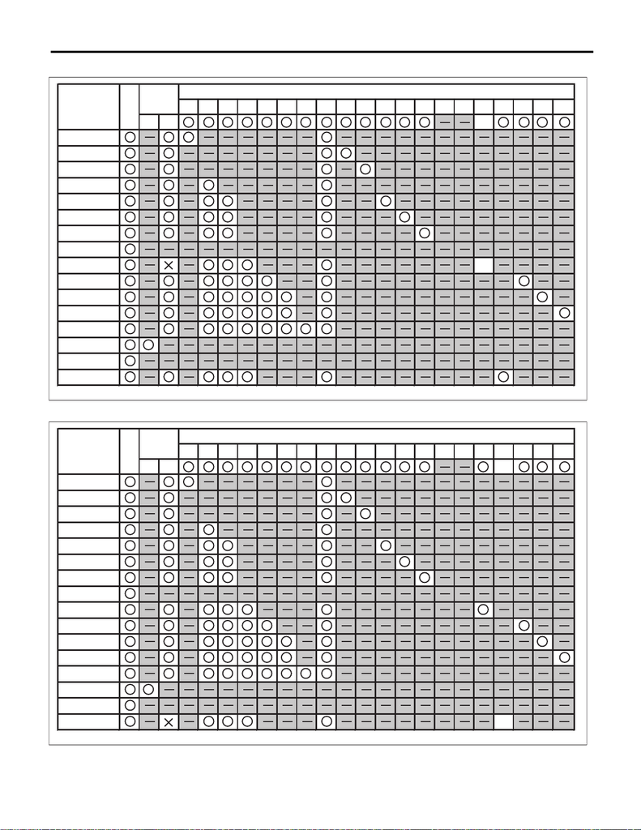

LAN(diag)-26

Subaru Select Monitor

LAN SYSTEM (DIAGNOSTICS)

• When No. 16 is open

• When No. 17 is open

LAN01461

(E)

(B)

(A)

IMP

RST

EGI(EJ)

EGI(FA)

DCCD

EPS

CVT

STR

MET

MFD

BIU

KPS

HL

VDC

(D)(C)

A/B

A/C

LAN01462

(E)

(B)

(A)

IMP

RST

EGI(EJ)

EGI(FA)

DCCD

EPS

CVT

STR

MET

MFD

BIU

KPS

HL

VDC

(D)(C)

A/B

A/C

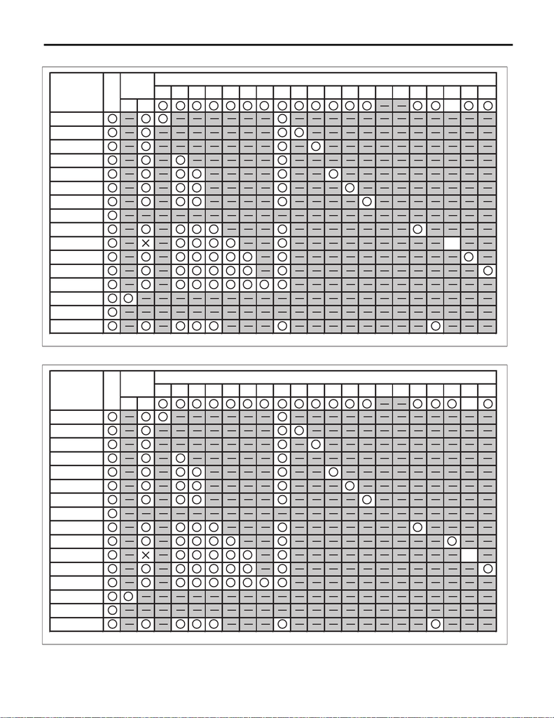

LAN(diag)-27

Subaru Select Monitor

LAN SYSTEM (DIAGNOSTICS)

• When No. 18 is open

• When No. 19 is open

LAN01463

(E)

(B)

(A)

IMP

RST

EGI(EJ)

EGI(FA)

DCCD

EPS

CVT

STR

MET

MFD

BIU

KPS

HL

VDC

(D)(C)

A/B

A/C

LAN01464

(E)

(B)

(A)

IMP

RST

EGI(EJ)

EGI(FA)

DCCD

EPS

CVT

STR

MET

MFD

BIU

KPS

HL

VDC

(D)(C)

A/B

A/C

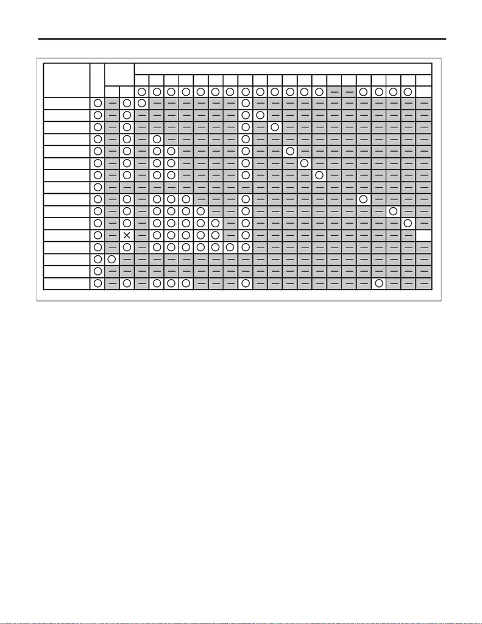

LAN(diag)-28

Subaru Select Monitor

LAN SYSTEM (DIAGNOSTICS)

• When No. 20 is open

LAN01465

(E)

(B)

(A)

IMP

RST

EGI(EJ)

EGI(FA)

DCCD

EPS

CVT

STR

MET

MFD

BIU

KPS

HL

VDC

(D)(C)

A/B

A/C